# Shiny: Introduction

Continuing Education - DIME Analytics

DIME Analytics

Development Impact Evaluation (DECDI)

Wednesday, the 1<sup>th</sup> of October, 2025

## Session Overview 📋

Welcome to this interactive Shiny session! In the next 90 minutes, we will:

1. **Understand what Shiny is** and why it’s useful
2. **Explore the structure** of a Shiny app: `UI` + `Server`
3. **Create our first Shiny app together** using the built-in template
4. Learn about **reactivity**, dynamic updates, and common **widgets**
5. **Build a multiple-file app** (`ui.R`, `server.R`, `global.R`)
6. Discover helpful **resources** and discuss your **next steps** 🚀

## Let’s Do This! 🚀

This session is **live at**: 🔗 [*https://ce-wb-shiny.netlify.app*](https://ce-wb-shiny.netlify.app/)

You can find the **quarto presentation** and the **final solutions** (both single-file and multiple-file apps) in our GitHub repository: 📦 [*https://github.com/dime-wb-trainings/shiny-training*](https://github.com/dime-wb-trainings/shiny-training)

[figure not shown]

## What Is Shiny?

> Shiny is a web application framework for R that allows you to turn analyses into interactive web apps — all in R.

[figure not shown]

**Why use it?**

- Easy to learn and use
- Fast development cycle
- Powerful for data visualization
- Built on R (leverage your analysis directly)
- Great for sharing insights interactively

## Anatomy of a Shiny App

A Shiny app has two core components:

- **UI (User Interface)**: Defines how the app looks
- **Server**: Defines how the app works

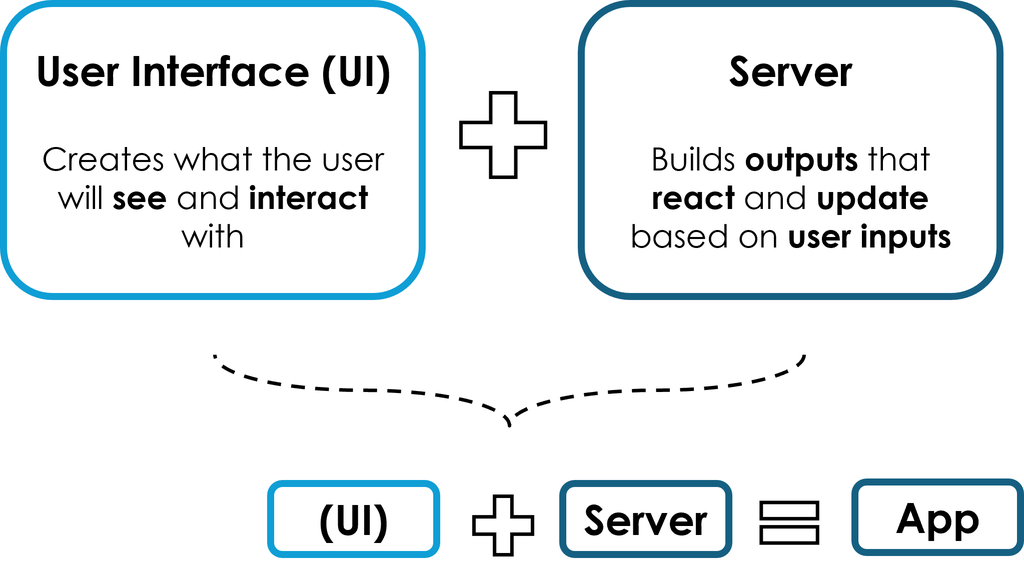

## The Client, Host, and Server

Apps are served to users via a host and port. The R session running the server reacts to user actions, computes results, and sends them back.

**Client**: The web browser where the user interacts with the app

**Host:Port**: Shiny app is served at an IP (host) and port

**Server**: Runs R session to monitor inputs and respond with outputs

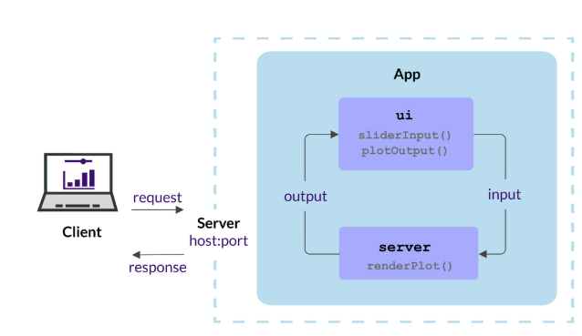

## Let’s Build Our First App Together (with the help of the R template) ✍️

**Step-by-step instructions:**

1. Open RStudio
2. If you haven’t already installed Shiny, run:

```r
install.packages("shiny")
```

3. Load the Shiny library:

```r
library(shiny)
```

4. Create a new Shiny Web App: Click on **File > New File > R Shiny Web App**

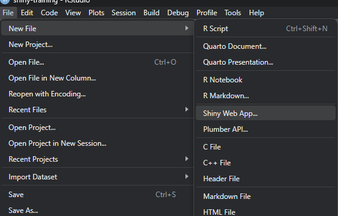

## Let’s Build Our First App Together (with the help of the R template) ✍️

5. Choose **Single File** option when prompted:

[figure not shown]

6. Name your folder and click OK

7. Click **Run App** in the top-right corner

8. 🎉 You’re running your first Shiny app!

## Let’s Explore the Code 🧠

> Go to the app you just created and let’s explore each element

### 1. `ui` — User Interface

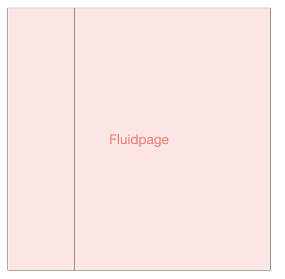

```r
ui <- fluidPage( #<<
  titlePanel("Old Faithful Geyser Data"),
  sidebarLayout(
    sidebarPanel(
      sliderInput("bins",
                  "Number of bins:",
                  min = 1,
                  max = 50,
                  value = 30)
    ),
    mainPanel(
      plotOutput("distPlot")
    )
  )
)
```

**Layout elements**

- **`fluidPage()`** is the container for the app interface, the layout in which your content is. This is the most common, but there are other types of layouts. Check [here](https://shiny.posit.co/r/articles/build/layout-guide/)

## Let’s Explore the Code 🧠

> Go to the app you just created and let’s explore each element

### 1. `ui` — User Interface

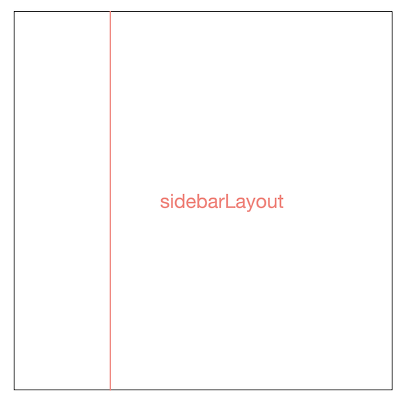

```r
ui <- fluidPage(
  titlePanel("Old Faithful Geyser Data"),
  sidebarLayout( #<<
    sidebarPanel(
      sliderInput("bins",
                  "Number of bins:",
                  min = 1,
                  max = 50,
                  value = 30)
    ),
    mainPanel(
      plotOutput("distPlot")
    )
  )
)
```

**Layout elements**

- **`sidebarLayout()`** splits the layout into sidebar (sidebarPanel()) and main area (mainPanel()). This is also optional.

## Let’s Explore the Code 🧠

> Go to the app you just created and let’s explore each element

### 1. `ui` — User Interface

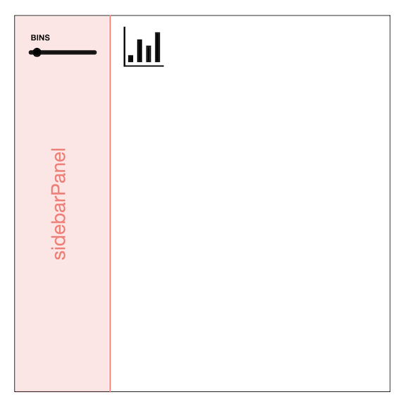

```r
ui <- fluidPage(
  titlePanel("Old Faithful Geyser Data"),
  sidebarLayout(
    sidebarPanel( #<<
      sliderInput("bins",  #<<
                  "Number of bins:",  #<<
                  min = 1, #<<
                  max = 50, #<<
                  value = 30) #<<
    ),
    mainPanel(
      plotOutput("distPlot")
    )
  )
)
```

**Page content**

- **`sidebarPanel()`** contains one input field (`sliderInput()`) called “bins”. This is a slider that lets a user choose a number. As you can infer from the name, in this case, it’s the number of histogram bins.

## Let’s Explore the Code 🧠

> Go to the app you just created and let’s explore each element

### 1. `ui` — User Interface

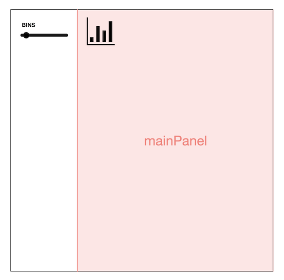

```r
ui <- fluidPage(
  titlePanel("Old Faithful Geyser Data"),
  sidebarLayout(
    sidebarPanel(
      sliderInput("bins",
                  "Number of bins:",
                  min = 1,
                  max = 50,
                  value = 30)
    ),
    mainPanel( #<<
      plotOutput("distPlot") #<<
    )
  )
)
```

**Page content**

- **`mainPanel()`** contains a histogram (`plotOutput()`), which will be defined in the server function. The name, or id, of this histogram is **“distPlot”**

## Shiny Server Logic Explained ⚙️

### 2. `server` — Server Logic

```r
server <- function(input, output) {
...
}
```

The `server()` function takes two arguments:

- `input`: a **reactive list** of input values from the UI
- `output`: a **reactive list** where you assign render functions

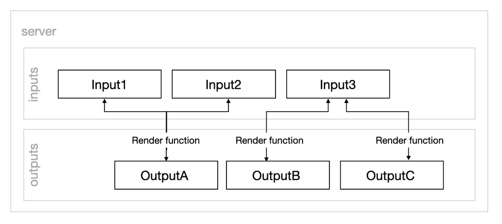

**Reactive lists** are “special” lists used in **reactive programming** — a way to make your app **automatically update** outputs when inputs change.

## Shiny Server Logic Explained ⚙️

### 2. `server` — Server Logic

```r
server <- function(input, output) {
  output$outputId <- renderFunction({
    value <- input$inputId
})
}
```

Let’s take a look at reactivity inside a simple `server( )`:

- **`renderFunction`**: A function like `renderPlot()`, `renderTable()`, etc. used to render an output (a plot, a table…)
- **`outputId`**: Identifies the rendered output in the output list (`output$`) for the UI
- The function regenerates **`value`** every time the input field referenced by **inputID** in the **input** list changes.

## Shiny Server Logic Explained ⚙️

### 2. `server` — Server Logic

```r
server <- function(input, output) {
  output$distPlot <- renderPlot({
    x <- faithful[, 2]
    bins <- seq(min(x), max(x), length.out = input$bins + 1)

    hist(x, breaks = bins, col = 'darkgray', border = 'white',
         xlab = 'Waiting time to next eruption (in mins)',
         main = 'Histogram of waiting times')
  })
}
```

In our case:

- the server contains the logic to create the histogram `distPlot` in the output list (`output$`), using the render function `renderPlot()`.
- `distPlot` depends on one user input (`input$bins`), which pulls the number from the slider input in the UI.

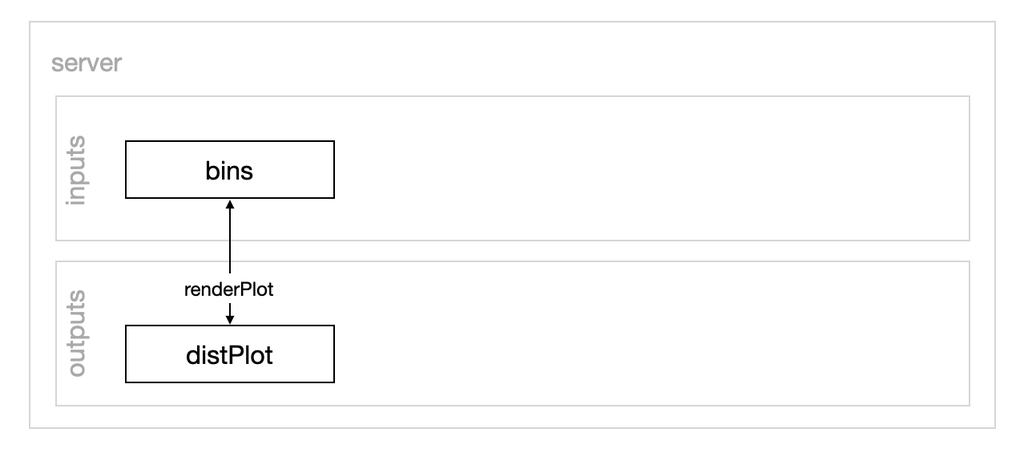

➡️️ **Result**: the histogram updates as the slider moves!

## Shiny Server Logic Explained ⚙️

### How Server Connects to UI 🧩

Remember these connections?

| UI | Server |
| --- | --- |
| `plotOutput("distPlot")` | `output$distPlot <- renderPlot()` |
| `sliderInput("bins", ...)` | `input$bins` |

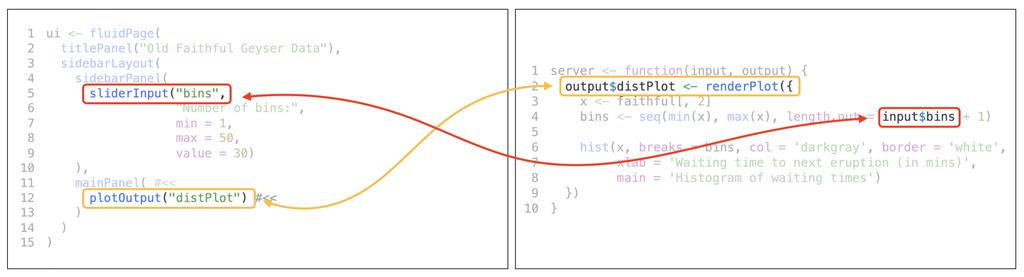

## Inputs & Outputs in Shiny 🧠

Shiny apps are built by connecting **inputs** (from the UI) to **outputs** (rendered in the server).

| Part | Role | Examples |
| --- | --- | --- |
| `ui` | Define layout and inputs/outputs | `sliderInput()`, `plotOutput()` |
| `server` | Logic to render outputs based on inputs | `renderPlot()`, `renderText()` |

🔁 **Reactivity** connects them:

- `input$...` pulls values from UI controls
- `output$... <- render...()` generates dynamic content

## A recap on Reactivity 🔁

- **Reactive programming** lets your app respond to changes without needing to re-run code manually.
- `input` and `output` behave like **reactive lists** — not regular R lists, but special objects in Shiny.
- When a user selects a value on the slider, say **5**, Shiny stores it as `input$bins = 5`.
- If the user changes it to **7**, Shiny automatically updates the `input` list — and any **render function** using it will re-execute.
- This is why `output$distPlot <- renderPlot({ ... input$bins ... })` updates **instantly**.

Together, `input`, `output`, and `render*()` functions form the **reactive backbone** of your app.

## Common Input Widgets 🛠️️

Shiny includes many built-in **widgets** to capture user input:

| Widget | Purpose | Example Use |
| --- | --- | --- |
| `numericInput()` | Enter a number | Age, price |
| `sliderInput()` | Select from a range | Histogram bins |
| `selectInput()` | Choose from a list | Country selector |
| `radioButtons()` | Choose one option | Plot type |
| `textInput()` | Enter text | Comments, filters |
| `fileInput()` | Upload a file | CSV, Excel |
| `actionButton()` | Trigger an action manually | Run, Submit |

📚 See the full gallery: ➡️ [Shiny Widgets Gallery](https://shiny.posit.co/r/gallery/widgets/widget-gallery/)

## Let’s start with some basic modifications ✍️

After your modifications the app should look like this:

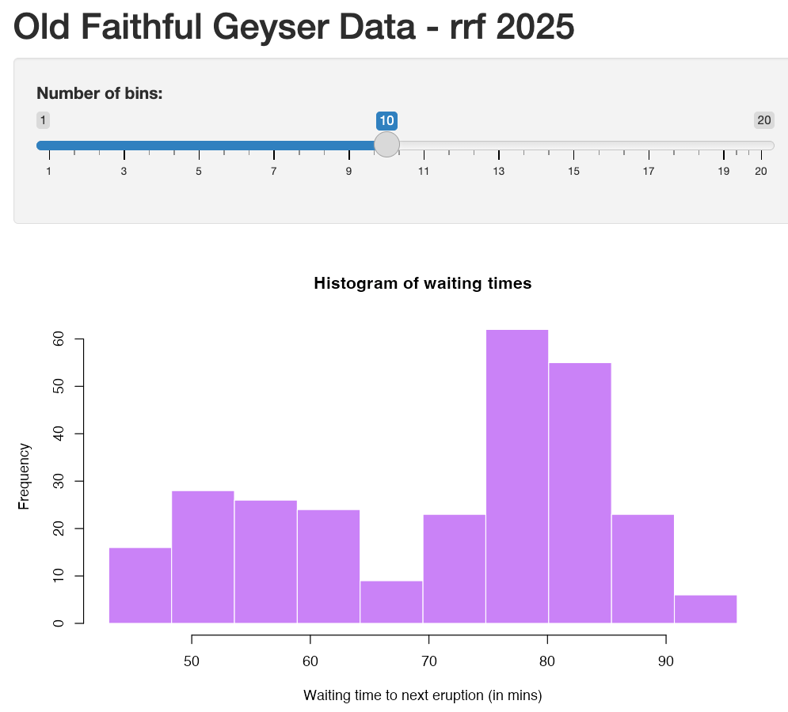

- The app with the modifications is available [here](https://github.com/dime-wb-trainings/shiny-training/blob/main/example_single/app.R)

## Behind the Scenes: Running a Shiny App ⚙️

Before you close the app, check the **R console**. You’ll see something like:

```
#> Listening on http://127.0.0.1:3827
```

🔍 **What it means:** - `127.0.0.1` refers to your local machine (“localhost”) - `3827` is a random port number - You can open the app in any browser using this address

⛔ **While the app is running:** - The R console is blocked (no new commands allowed) - A stop sign appears in the RStudio toolbar

🛑 **To stop the app:** - Click the stop sign icon - Press `Esc` (or `Ctrl + C` in terminal) - Close the Shiny app window

## Questions

[figure not shown]

## Building a Multiple -File App 🏗️

As your app grows, managing everything in a **single file** becomes difficult. That’s why it’s a good idea to switch to a **multi-file structure** — this is the recommended approach.

Let’s walk through how to set it up!

1. In RStudio, go to  
   **`File > New File > Shiny Web App…`**
2. This time, choose **“Multiple File”** when prompted:

[figure not shown]

## Building a Multiple -File App 🏗️

3. Name your project folder and click OK. This will automatically create two files.

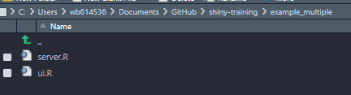

4. Lastly let’s create an extra file `global.R`. (Optional but recommended) This file is useful for loading packages and defining global objects or functions used by both `ui.R` and `server.R`.

5. Click the **Run App** button in the top-right corner of RStudio.

## ✨ Now Let’s Make It More Interesting

- You’ve set up a multiple-file **Shiny app**—great start! Now let’s **customize it together**.
- We’ll go through a series of **hands-on exercises** using the `faithful` dataset to:
  - Add new **UI components**
  - Enhance **server logic**
- After each exercise, we’ll do a **live walkthrough** to see how the changes integrate into the app.

📝 **Note:** While we’re using the files created by RStudio as a starting point, you’re not limited to that setup. You can always:

- Create a Shiny app by saving your own `.R` scripts as `ui.R` and `server.R`
- Or combine everything into a single `app.R` file if you prefer that style

## Exercise 1: Add a Custom Title and Subtitle ✍️

Let’s improve the layout and presentation of your app!

### 📝 Your task:

- In `ui.R`, replace the `titlePanel()` with:
  - A custom **title**
  - A smaller **subtitle** using `h3()`

### 🔍 Hint:

```r
titlePanel("Faithful Geyser Data - Customized"),
h3("Exploring waiting times between eruptions")
```

## Exercise 2: Add a Color Selector ✍️

Let’s make the histogram more interactive!

### 📝 Your task:

- Add a `selectInput()` to the `sidebarPanel()` so users can choose a color for the histogram
- Then use `input$color` inside `renderPlot()` to apply the color.

### 🔍 Hint:

UI:

```r
 selectInput("color", "Choose a color:", choices = c("turquoise", "plum", "orchid"))
```

Server:

```r
col = input$color
```

## ✅ Solution: Exercise 2

- Let’s do this together.

See that if I don’t add the `input$color` in the server inside the `hist()` function, the color will not change.

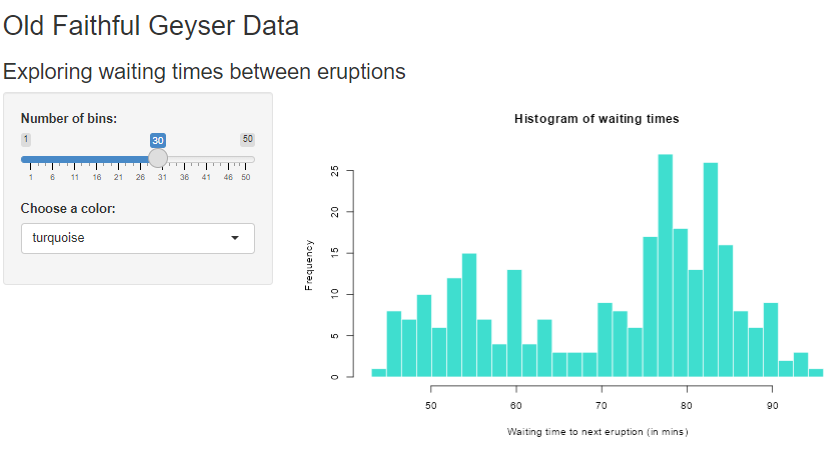

## Exercise 3: Add a Plot Type Selector ✍️

Ok! now let’s make this more challenging! Let’s give the user control over the **type of plot** they see!

### 🔍 Hint:

UI:

```r
radioButtons("plot_type", "Choose a plot type:",
             choices = c("Histogram", "Density"))
```

In `server.R`, check the value of `input$plot_type` to decide which plot to draw.

## ✅ Solution: Exercise 3

Full server logic:

### `server.R`

```r
function(input, output, session) {

    output$distPlot <- renderPlot({

        # generate bins based on input$bins from ui.R
        x    <- faithful[, 2]

        if (input$plot_type == "Histogram") {

        bins <- seq(min(x), max(x), length.out = input$bins + 1)

        # draw the histogram with the specified number of bins
        hist(x, breaks = bins, col = input$color, border = 'white',
             xlab = 'Waiting time to next eruption (in mins)',
             main = 'Histogram of waiting times')
        } else if (input$plot_type == "Density")
          {
          ggplot(faithful, aes(x=x)) +
            geom_density(alpha = 0.5, color = input$color) +
            labs(x = 'Waiting time to next eruption (in mins)',
                 title = 'Density Plot of Waiting Times') +
            theme_minimal()
          }

    })

}
```

## Exercise 4: Adding an Intro Tab ✍️

It’s always good practice to **explain what your app does**. For this, we can create an *intro tab* — like a README page — that gives your users helpful context.

1. Add a `tabsetPanel()` inside the `mainPanel()`.
2. Create two tabs:
   - One for the plot
   - One for the **Introduction**
3. In the Intro tab, write a short description of what the app does (in plain text or with HTML).

### ✅ Solution: Exercise 4

Here’s how your `ui.R` could look after adding the tabs:

```r
# Define UI for application that draws a histogram
navbarPage("Faithful Geyser Data - Customized",
           tabPanel("Introduction",
                      h3("Exploring the Faithful Geyser Data"),
                      p("This application allows you to visualize the waiting times between eruptions of the Old Faithful geyser.
                          You can choose between a histogram and a density plot, adjust the number of bins, and select a color for the plot.")

                    ),

           tabPanel("Plots",

                    # Sidebar with a slider input for number of bins
                    sidebarLayout(
                      sidebarPanel(
                        sliderInput("bins",
                                    "Number of bins:",
                                    min = 1,
                                    max = 50,
                                    value = 30),
                        selectInput("color", "Choose a color:", choices = c("turquoise", "plum", "orchid")),
                        radioButtons("plot_type", "Choose a plot type:",
                                     choices = c("Histogram", "Density"))
                      ),

                      # Show a plot of the generated distribution
                      mainPanel(
                        plotOutput("distPlot")
                      )
                    )
           ))
```

## Exercise 5: Add a Theme ✍️

Want your app to look more polished? Shiny supports easy theming with the `{bslib}` package.

👉 **Your task**: Add a custom theme to your app!

### 🔧 Steps

1. **Load** the `bslib` package in your `global.R` file:

   ```r
   library(bslib)
   ```

   If you don’t have it installed, run:

   ```r
   install.packages("bslib")
   ```

2. **Wrap your `navbarPage()`** in a `thematic` Bootstrap theme `ui.R` file:

   ```r
     theme = bs_theme(bootswatch = "minty") # Try "minty", "flatly", "journal", etc.
   ```

3. **Save** and re-run your app!

## Add a Theme ✍️

### ✨ More bootswatch themes

- `"flatly"` (clean + modern)
- `"darkly"` (dark mode)
- `"minty"` (playful + bright)
- `"journal"` (serif style)
- Full list: https://bootswatch.com

## Extra if there is time: Add Download Functionality ✍️

Let’s allow users to **download the dataset** they are exploring!

### 📝 Your task:

- Add a **`downloadButton()`** to the UI so users can download the data.
- In `server.R`, define a **`downloadHandler()`** to write the `faithful` dataset as a CSV file.

### 🔍 Hint:

- You will use `downloadButton()` in the ui and `downloadHandler()` in the server.

## ✅ Solution: Exercise Extra

### `ui.R`

```r
downloadButton("download_data", "Download Data")
```

### `server.R`

```r
output$download_data <- downloadHandler(
  filename = function() { "faithful_data.csv" },
  content = function(file) {
    write.csv(faithful, file, row.names = FALSE)
  }
)
```

- The multiple file app with all the exercises we did is available [here](https://github.com/dime-wb-trainings/shiny-training/tree/main/example_multiple)

## Exercise Extra 2: Add Table Tab✍️

Let’s add a new tab to display the `faithful` dataset as a table.

### 📝 Your task:

- Create a new tab in `ui.R` called “Table”.
- In the new tab, use `tableOutput("data_table")` to display the dataset.
- In `server.R`, create a new output called `data_table` that renders the `faithful` dataset as a table.

### 🔍 Hint:

- Use `renderTable()` in the server to display the dataset.

## ✅ Solution: Exercise Extra 2

### `ui.R`

```r
tabPanel("Table",
             h2("Faithful Geyser Data Table"),
             p("Below is the table of the Old Faithful geyser data. You can view the waiting times between eruptions."),
             tableOutput("data_table"))
```

### `server.R`

```r
output$data_table <- renderTable({
  faithful
})
```

- The multiple file app with all the exercises we did is available [here](https://github.com/dime-wb-trainings/shiny-training/tree/main/example_multiple)
- Note: this is not super aesthetic, but you can use packages like `{DT}` or `{reactable}` to make it look better.

## Share your Shiny app

- 🏢 **Posit Connect Internal Server**
  - Recommended option for **secure deployment within the Bank**
  - Content is deployed on Bank server behind a firewall, **only accessible to Bank employees**
- 🌐 **Posit Connect Public Server**
  - Content is deployed on Bank server behind a firewall, but accessible to all.
  - **Only display public use data**

For both:

- Push-button publishing from RStudio or publish directly from GitHub
- Request Posit Connect access as a Software Request
- [Learn more](https://posit.co/products/enterprise/connect/), [Internal Resources](https://w0lxdrconn01.worldbank.org/user-guide/wb-connect-users-guide.html)

## Share your Shiny app

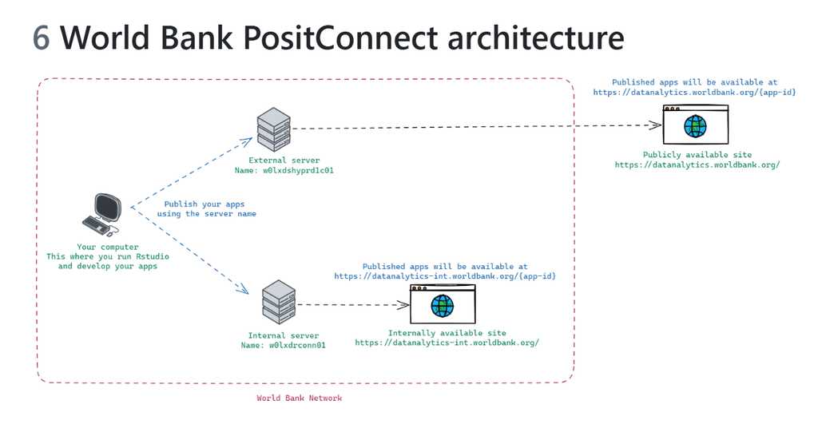

## Thank you! 🙏

[figure not shown]

## Additional Resources 📚

Want to go further with Shiny? Here are some helpful resources:

- 🧪 **Shiny Tutorial** (Official Getting Started Guide) [here](https://shiny.posit.co/tutorial)
- 📘 **Mastering Shiny** by Hadley Wickham (Free online book) [here](https://mastering-shiny.org)
- 💡 **Shiny Widgets Gallery** [here](https://shiny.posit.co/r/gallery/widgets/widget-gallery/)
- 🧩 **Awesome Shiny Extensions** (Community plugins) [here](https://github.com/nanxstats/awesome-shiny-extensions)
- 🌐 **Shiny Community** (Forums, discussions) [here](https://community.rstudio.com/c/shiny)
- 📦 **Building Web Applications** (Training) [here](https://rstudio-education.github.io/shiny-course/)
- 🧱 **Adding multiple objects in layout** [here](https://shiny.posit.co/r/reference/shiny/0.14/column.html)

## Some examples ✨

- Shiny App Gallery [here](https://shiny.posit.co/r/gallery/)
- California Schools Climate Hazards Dashboard [here](https://schoolclimatehazards.grit.ucsb.edu/)
- New Zealand Trade Intelligence Dashboard [here](https://gallery.shinyapps.io/nz-trade-dash)
- Locating Blood Banks in India [here](https://opndt.shinyapps.io/bloodbank_india/)
- Understanding voters’ profile in Brazilian elections [here](https://shiny.posit.co/r/gallery/government-public-sector/brazil-voter-profile/)